# Ch 22 Text Mining

## Exercises

> Project Gutenberg is a digital archive of public domain books. The R package **gutenbergr** facilitates the importation of these texts into R.

> You can install and load it like this:

> ```r
> install.packages("gutenbergr")
> library(gutenbergr)
> ```

> You can see the books that are available like this:

> ```r
> gutenberg_metadata
> ```

```r
#install.packages("gutenbergr")
library(gutenbergr)
library(tidyverse)
```

> 1. Use `str_detect` to find the ID of the novel *Pride and Prejudice*.

Since the numeration in the gutenberg data starts with zero, we need to decrease the indexes by one. Here, I use the function `str_which` that combines the commands `str_detect` and `which`.

```r
idx <- gutenberg_metadata %>% .$title %>% str_which("Pride and Prejudice") %>% .[]-1
```

In total we get 6 hits for the book “Pride and Prejudice”.

```r
gutenberg_metadata %>% filter(gutenberg_id %in% idx)
```

| gutenberg_id | title | author | gutenberg_author_id | language | gutenberg_bookshelf | rights | has_text |
| --- | --- | --- | --- | --- | --- | --- | --- |
| 1342 | Pride and Prejudice | Austen, Jane | 68 | en | Best Books Ever Listings/Harvard Classics | Public domain in the USA. | TRUE |
| 20686 | Pride and Prejudice | Austen, Jane | 68 | en | Harvard Classics/Best Books Ever Listings | Public domain in the USA. | FALSE |
| 20687 | Pride and Prejudice | Austen, Jane | 68 | en | Harvard Classics/Best Books Ever Listings | Public domain in the USA. | FALSE |
| 26301 | Pride and Prejudice | Austen, Jane | 68 | en | Best Books Ever Listings | Public domain in the USA. | FALSE |
| 37431 | Pride and Prejudice, a play founded on Jane Austen's novel | NA | NA | en | NA | Public domain in the USA. | TRUE |
| 42671 | Pride and Prejudice | Austen, Jane | 68 | en | Best Books Ever Listings | Public domain in the USA. | TRUE |

> 2. We notice that there are several versions. The `gutenberg_works()` function filters this table to remove replicates and include only English language works. Read the help file and use this function to find the ID for *Pride and Prejudice*

After removing the duplicates we end up with just two titles.

```r
gutenberg_works() %>% filter(gutenberg_id %in% idx)
```

| gutenberg_id | title | author | gutenberg_author_id | language | gutenberg_bookshelf | rights | has_text |
| --- | --- | --- | --- | --- | --- | --- | --- |
| 1342 | Pride and Prejudice | Austen, Jane | 68 | en | Best Books Ever Listings/Harvard Classics | Public domain in the USA. | TRUE |
| 37431 | Pride and Prejudice, a play founded on Jane Austen's novel | NA | NA | en | NA | Public domain in the USA. | TRUE |

> 3. Use the `gutenberg_download` function to download the text for Pride and Prejudice. Save it to an object called `book`.

```r
book <- gutenberg_download(gutenberg_id = 1342)
```

```
## Determining mirror for Project Gutenberg from http://www.gutenberg.org/robot/harvest
```

```
## Using mirror http://aleph.gutenberg.org
```

```r
str(book)
```

```
## Classes 'tbl_df', 'tbl' and 'data.frame':    13030 obs. of  2 variables:
##  $ gutenberg_id: int  1342 1342 1342 1342 1342 1342 1342 1342 1342 1342 ...
##  $ text        : chr  "PRIDE AND PREJUDICE" "" "By Jane Austen" "" ...
```

> 4. Use the **tidytext** package to create a tidy table with all the words in the text.

```r
library(tidytext)
book_tok <-book %>% unnest_tokens(word, text)
book_tok
```

| gutenberg_id | word |
| --- | --- |
| 1342 | pride |
| 1342 | and |
| 1342 | prejudice |
| 1342 | by |
| 1342 | jane |
| 1342 | austen |
| 1342 | chapter |
| 1342 | 1 |
| 1342 | it |
| 1342 | is |

[output cut: 9990 more lines]

> 5. We will later make a plot of sentiment versus location in the book. For this, it will be useful to add a column with the word number to the table.

```r
book_tok <- book_tok %>% mutate(word_number = row_number())
```

> 6. Remove the stop words and numbers from the `stop_words` object. Hint: use the `anti_join`.

```r
book_words <- anti_join(book_tok,stop_words, by="word")%>% filter(!word %in% c(1:100)) %>% arrange(word)
book_words
```

| gutenberg_id | word | word_number |
| --- | --- | --- |
| 1342 | 15th | 18429 |
| 1342 | 18th | 18738 |
| 1342 | 26th | 81081 |
| 1342 | _accident_ | 43753 |
| 1342 | _advantages_ | 55544 |
| 1342 | _affect_ | 65363 |
| 1342 | _all_ | 10392 |
| 1342 | _all_ | 11506 |
| 1342 | _all_ | 36880 |
| 1342 | _all_ | 81118 |

[output cut: 9990 more lines]

> 7. Now use the `AFINN` lexicon to assign a sentiment value to each word.

```r
afinn <- sentiments %>% filter(lexicon == "AFINN") %>% select(word, score)
book_score <- inner_join(book_words,afinn,by="word")
```

> 8. Make a plot of sentiment score versus location in the book and add a smoother.

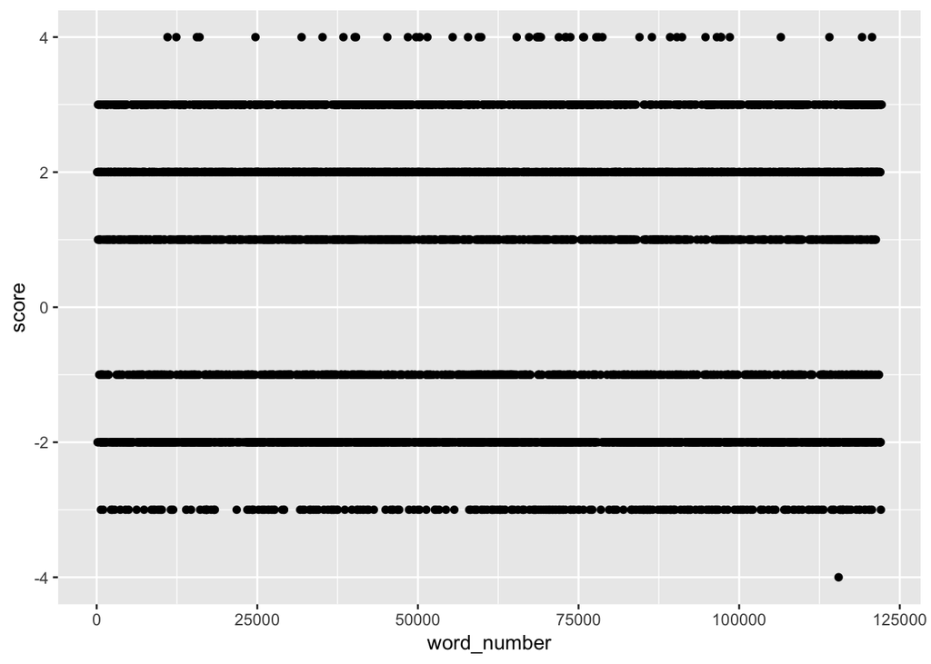

```r
book_score %>% ggplot(aes(word_number,score)) + geom_point()
```

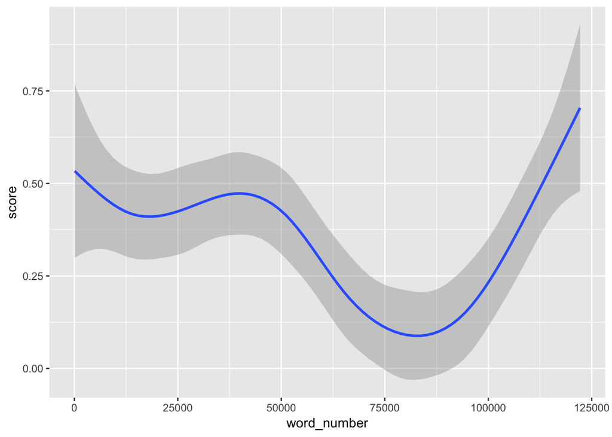

```r
book_score %>% ggplot(aes(word_number,score)) + geom_smooth()
```

> 9. Assume there are 300 words per page. Convert the locations to pages and then compute the average sentiment in each page. Plot that average score by page. Add a smoother that appears to go through data.

```r
book_page <- book_score %>% mutate(page_number = round(word_number/300))
```

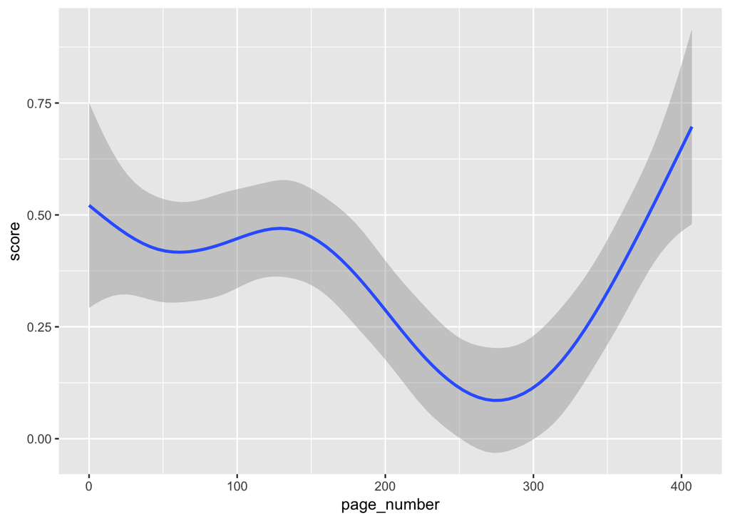

```r
book_page %>% ggplot(aes(page_number,score)) + geom_smooth()
```